# MolBreeding (GBTS) vs skim — simulation-calibrated comparison

Author

Fausto Rodríguez-Zapata

Published

June 17, 2026

**Repo:** sawers-rellan-labs/zealtiger

> **STATUS: skim + GBTS done.** Simulation-calibrated successor to `molbreeding_vs_skim.qmd`. The original is kept **frozen** (`docs/molbreeding_vs_skim.html`); outputs here are **isolated** to `results/sim_calibration/`. Promote to the canonical name only once validated.

## What this adds over the old comparison

The old `molbreeding_vs_skim` is a **direct** GBTS-vs-skim comparison at a shared, borrowed `r=8`. This notebook instead (i) **calibrates the coverage model from the real skim** — the per-sample λ Gamma shape is *fit* (≈8), not assumed (the old 2.5) — so the degraded sim matches the real skim’s coverage; (ii) **derives the rigidity** by sweeping FP+FN against the simulated truth (→ **r=5** for skim, not 8; `docs/14`); and (iii) uses the **three-`f_i` bias decomposition** (`docs/13` §5c-d): real calls are compared to the **degraded-simulation** reference (method bias), not directly to p₀, so `(real − degraded-sim)` isolates real biology. Both sides are at the derived r=5.

## Setup

```r
library(tidyverse); library(data.table)
purrr::walk(fs::dir_ls("R", glob = "*.R"), source)
set.seed(params$seed)
fs::dir_create(file.path(params$out_dir, "figures"))

p0 <- single_locus_p0(n_bc = 2L, n_self = 3L)   # breeding-scheme expectation

# per-file raw-count coverage stats (missingness / depth / observed-het-rate)
count_stats <- function(path, name) {
  d <- fread(path, header = FALSE, col.names = c("chr","pos","rb","ref","ab","alt"))
  dep <- d$ref + d$alt
  data.frame(name = name, missing = mean(dep == 0), mean_depth = mean(dep),
             het_rate = mean(d$ref > 0 & d$alt > 0))
}
# per-sample REF/Het/ALT Mb fractions from a state-segment table
seg_fractions <- function(seg) {
  seg %>% mutate(mb = (end_bp - start_bp) / 1e6) %>%
    group_by(name) %>%
    summarise(REF = sum(mb[state == 0]), Het = sum(mb[state == 1]),
              ALT = sum(mb[state == 2]), .groups = "drop") %>%
    mutate(tot = REF + Het + ALT) %>% filter(tot > 0) %>%
    transmute(name, REF = REF/tot, Het = Het/tot, ALT = ALT/tot)
}
cat(sprintf("p0  REF %.3f  Het %.3f  ALT %.3f\n", p0["REF"], p0["Het"], p0["ALT"]))
```

```
p0  REF 0.859  Het 0.031  ALT 0.109
```

# Skim (Source 2, SNP50K ~0.4×)

## Layer 2 — Observation model (skim)

Does the coverage model reproduce the **real** skim’s coverage behaviour? The exp-floor missingness (`draw_allele_counts`, π=0.161, k=1.042) plus the per-sample λ **Gamma fit from the real skim** (mean 0.44, **shape ≈8**, floor 0.10 — not the old assumed 2.5). Compare missingness %, mean depth, and *observed* het-rate (sites with both ref>0 and alt>0 in raw counts) between real skim and the degraded simulation.

```r
ed <- read_csv(params$skim_design, show_col_types = FALSE) %>% slice_sample(n = params$n_skim_obs)
real_stats <- purrr::map2_dfr(ed$files, ed$name, count_stats) %>% mutate(source = "real skim")
sf <- fs::dir_ls(file.path(params$bench, "counts"), glob = "*.tsv")
sim_stats <- purrr::map2_dfr(as.character(sf), tools::file_path_sans_ext(basename(sf)),
                             count_stats) %>% mutate(source = "degraded sim")
obs <- bind_rows(real_stats, sim_stats)

obs %>% group_by(source) %>%
  summarise(n = n(), missing = mean(missing), mean_depth = mean(mean_depth),
            obs_het_rate = mean(het_rate), .groups = "drop") %>%
  knitr::kable(digits = 4)
```

| source | n | missing | mean_depth | obs_het_rate |
| --- | --- | --- | --- | --- |
| degraded sim | 100 | 0.6966 | 0.4413 | 0.0030 |
| real skim | 60 | 0.7140 | 0.4136 | 0.0012 |

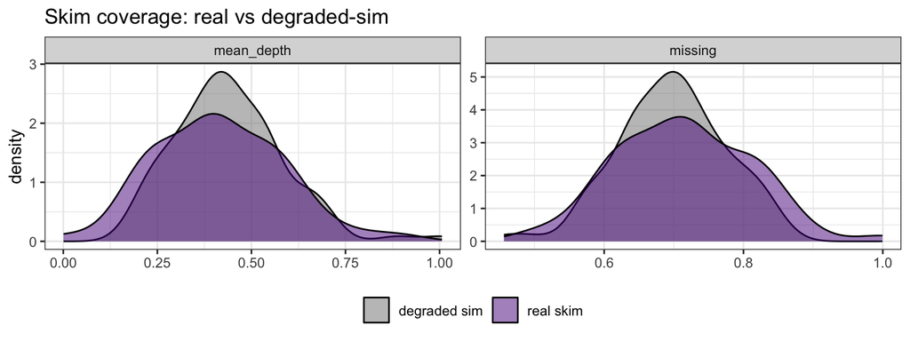

```r
obs %>% select(source, missing, mean_depth) %>%
  pivot_longer(c(missing, mean_depth)) %>%
  ggplot(aes(value, fill = source)) +
  geom_density(alpha = 0.5) + facet_wrap(~name, scales = "free") +
  scale_fill_manual(values = c("real skim" = "purple4", "degraded sim" = "grey50")) +
  labs(x = NULL, fill = NULL, title = "Skim coverage: real vs degraded-sim") +
  theme_bw() + theme(legend.position = "bottom")
```

**Read:** with the **fitted** Gamma (shape ≈8 vs the old 2.5) the missingness *and* depth distributions now match real (real CV ≈0.35 ≈ sim) — the old shape 2.5 was over-dispersed; observed het-rate is tiny in both (≈0.1–0.3 %), the severe raw-count het-undercall ~1.5-read coverage forces. The observation model is validated.

## Layer 3 — Recovery (degraded sim, r = 5)

RTIGER on the degraded truth at the **derived r = 5** (the FP+FN argmin from the truth sweep; `docs/14`), scored against the known truth (`R/06_score_rtiger.R`). This is the **method-bias** term: what the skim pipeline does to a *known-neutral* truth.

```r
sc <- file.path(params$bench, "scoring")
read_csv(file.path(sc, "segment_scores.csv"), show_col_types = FALSE) %>%
  select(class, n_truth, n_called, precision, recall, F1, med_start_err_kb) %>%
  knitr::kable(digits = 3, caption = "Segment recovery (reciprocal overlap ≥ 0.5)")
```

Segment recovery (reciprocal overlap ≥ 0.5)

| class | n_truth | n_called | precision | recall | F1 | med_start_err_kb |
| --- | --- | --- | --- | --- | --- | --- |
| homozygous_donor | 845 | 797 | 0.995 | 0.938 | 0.966 | 84.833 |
| heterozygous | 477 | 414 | 0.957 | 0.830 | 0.889 | 127.250 |
| donor_present | 1322 | 1211 | 0.989 | 0.906 | 0.946 | 84.836 |

```r
read_csv(file.path(sc, "crossover_scores.csv"), show_col_types = FALSE) %>%
  knitr::kable(digits = 3, caption = "Crossover-count recovery")
```

Crossover-count recovery

| call_set | mean_true_co | mean_called_co | co_bias | co_rmse |
| --- | --- | --- | --- | --- |
| RTIGER | 20.6 | 18.89 | -1.71 | 2.377 |

**Read:** donor segments recover well (F1 ≈ 0.95); **het is the weaker class** (F1 ≈ 0.89, recall ≈ 0.83 — small het segments missed) and crossovers undercount (bias ≈ −1.7). This is the skim’s method bias at the *segment* level. Note (next section) it largely cancels at the *genome-fraction* level.

## Three-`f_i` decomposition (skim)

1. p₀ (neutral breeding) — (2) degraded-sim calls (method bias) — (3) real skim calls (bias + biology). The correct reference for the real data is **(2)**, not p₀.

```r
sim_f  <- seg_fractions(read_rtiger_segments(file.path(params$bench, "rtiger_out_r5", "rtiger_result.rds")))
real_f <- seg_fractions(read_csv(params$skim_calls, show_col_types = FALSE) %>%
                          transmute(name, chr, start_bp, end_bp, state))
fi <- tibble(
  f_i = factor(c("(1) p0 breeding", "(2) degraded-sim", "(3) real skim"),
               levels = c("(1) p0 breeding", "(2) degraded-sim", "(3) real skim")),
  REF = c(p0["REF"], mean(sim_f$REF), mean(real_f$REF)),
  Het = c(p0["Het"], mean(sim_f$Het), mean(real_f$Het)),
  ALT = c(p0["ALT"], mean(sim_f$ALT), mean(real_f$ALT)),
  n   = c(NA, nrow(sim_f), nrow(real_f)))
knitr::kable(fi, digits = 4)
```

| f_i | REF | Het | ALT | n |
| --- | --- | --- | --- | --- |
| (1) p0 breeding | 0.8594 | 0.0312 | 0.1094 | NA |
| (2) degraded-sim | 0.8674 | 0.0288 | 0.1038 | 100 |
| (3) real skim | 0.8900 | 0.0755 | 0.0345 | 1393 |

```r
cat(sprintf("(2)-(1) method bias:  Het %+.4f  ALT %+.4f\n",
            fi$Het[2]-fi$Het[1], fi$ALT[2]-fi$ALT[1]))
```

```
(2)-(1) method bias:  Het -0.0024  ALT -0.0056
```

```r
cat(sprintf("(3)-(2) real biology: Het %+.4f  ALT %+.4f\n",
            fi$Het[3]-fi$Het[2], fi$ALT[3]-fi$ALT[2]))
```

```
(3)-(2) real biology: Het +0.0467  ALT -0.0693
```

```r
write_csv(fi, file.path(params$out_dir, "skim_three_fi.csv"))
```

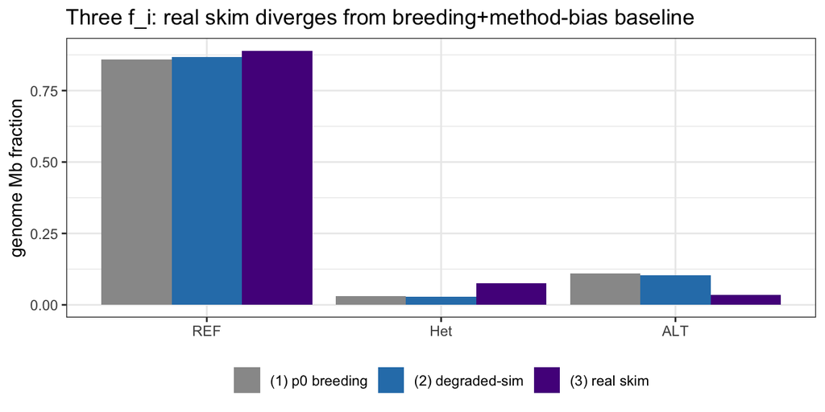

```r
fi %>% select(-n) %>% pivot_longer(c(REF, Het, ALT), names_to = "state") %>%
  mutate(state = factor(state, c("REF", "Het", "ALT"))) %>%
  ggplot(aes(state, value, fill = f_i)) +
  geom_col(position = "dodge") +
  scale_fill_manual(values = c("(1) p0 breeding"="grey60", "(2) degraded-sim"="#2c7fb8",
                               "(3) real skim"="purple4")) +
  labs(x = NULL, y = "genome Mb fraction", fill = NULL,
       title = "Three f_i: real skim diverges from breeding+method-bias baseline") +
  theme_bw() + theme(legend.position = "bottom")
```

**Read — the payoff.** Method bias on the *fraction* is negligible (`(2)−(1)` ≈ Het −0.002 / ALT −0.006): RTIGER at r=5 recovers genome-wide fractions near p₀ even though it misses ~17 % of het *segments* (the missed het is small, so little Mb is lost). The real signal is `(3)−(2)`: **Het ≈ +0.047 and ALT ≈ −0.069** — the real skim NILs carry roughly **2.6× the heterozygosity and ~⅓ the homozygous-donor** the neutral BC2S3 scheme predicts (donor dosage **0.072 vs 0.125**), and this is **not** a method artifact. That’s a genuine biological deviation (heterozygote excess / donor-homozygote deficit → selection against donor homozygotes, residual heterozygosity, or paralog mis-mapping inflating het) — the question `docs/12-het-excess-diagnosis.md` takes up. The simulation baseline is what makes this separable: without (2) you couldn’t tell method bias from biology.

# GBTS (Source 5, ~110× target-capture, wideseq-filtered)

The wideseq-filtered (`SNP_wsfilt`) **high-confidence** set: 9,157 sites validated in prior genotyping and selected for clean Poisson coverage in the skim. ~100% covered at **~110×** (capped to **20×** for the betabinomial fit cost), so het is **resolved** — the opposite regime to the skim. Informative density ~4.3/Mb (sparser than skim’s 6.7; GBTS’s edge is *coverage*, not marker count). Derived rigidity **r=2** (FP+FN sweep vs truth — see below; *not* the borrowed r=8).

## Layer 2 — Observation model (GBTS)

```r
g <- data.table::fread(params$gbts_gatk)
real <- g[, .(depth = mean(TOTAL_COUNT), missing = mean(TOTAL_COUNT == 0),
              het = mean(REF_COUNT > 0 & ALT_COUNT > 0)), by = SAMPLE]
ss <- read_csv(file.path(params$gbts_bench, "sample_stats.csv"), show_col_types = FALSE)
tibble(source = c("real GBTS (raw)", "real GBTS (capped 20×, fit input)", "degraded sim (20×)"),
       mean_depth  = c(mean(real$depth), 20, mean(ss$mean_depth)),
       missingness = c(mean(real$missing), mean(real$missing), mean(ss$missing_obs)),
       obs_het_rate = c(mean(real$het), NA, NA)) %>%
  knitr::kable(digits = 4)
```

| source | mean_depth | missingness | obs_het_rate |
| --- | --- | --- | --- |
| real GBTS (raw) | 110.1883 | 0.0012 | 0.086 |
| real GBTS (capped 20×, fit input) | 20.0000 | 0.0012 | NA |
| degraded sim (20×) | 20.0042 | 0.0012 | NA |

**Read:** real GBTS is ~110×, ~0.1 % missing — near-complete. The betabinomial fit cost caps it to **20×** (the fit input), which the sim benchmark matches (20×, ~0.1 % missing). At 20× het is fully resolved (vs the skim’s ~1.5 reads), so there is **no het-undercall** here. Observation model validated at the capped level.

## Layer 3 — Recovery (degraded sim, r = 2)

```r
sc <- file.path(params$gbts_bench, "scoring")
read_csv(file.path(sc, "segment_scores.csv"), show_col_types = FALSE) %>%
  select(class, n_truth, n_called, precision, recall, F1) %>%
  knitr::kable(digits = 3, caption = "GBTS segment recovery at r=2 (reciprocal overlap ≥ 0.5)")
```

GBTS segment recovery at r=2 (reciprocal overlap ≥ 0.5)

| class | n_truth | n_called | precision | recall | F1 |
| --- | --- | --- | --- | --- | --- |
| homozygous_donor | 851 | 834 | 1.000 | 0.980 | 0.990 |
| heterozygous | 452 | 432 | 0.986 | 0.942 | 0.964 |
| donor_present | 1303 | 1266 | 0.999 | 0.971 | 0.985 |

```r
read_csv(file.path(sc, "crossover_scores.csv"), show_col_types = FALSE) %>%
  knitr::kable(digits = 3, caption = "GBTS crossover recovery")
```

GBTS crossover recovery

| call_set | mean_true_co | mean_called_co | co_bias | co_rmse |
| --- | --- | --- | --- | --- |
| RTIGER | 20.38 | 19.9 | -0.48 | 1.01 |

**Read:** recovery is excellent — donor F1 ≈ 0.99, **het F1 ≈ 0.96**, CO bias ≈ −0.5 (vs skim’s 0.95 / 0.89 / −1.7). High coverage resolves the het and crossovers the skim misses, so the **method bias is minimal**.

## Three-`f_i` decomposition (GBTS)

```r
sim_g  <- seg_fractions(read_rtiger_segments(file.path(params$gbts_bench, "rtiger_out_r2", "rtiger_result.rds")))
real_g <- seg_fractions(read_csv(params$gbts_calls, show_col_types = FALSE) %>%
                          transmute(name, chr, start_bp, end_bp, state))
fig <- tibble(
  f_i = factor(c("(1) p0 breeding", "(2) degraded-sim", "(3) real GBTS"),
               levels = c("(1) p0 breeding", "(2) degraded-sim", "(3) real GBTS")),
  REF = c(p0["REF"], mean(sim_g$REF), mean(real_g$REF)),
  Het = c(p0["Het"], mean(sim_g$Het), mean(real_g$Het)),
  ALT = c(p0["ALT"], mean(sim_g$ALT), mean(real_g$ALT)),
  n   = c(NA, nrow(sim_g), nrow(real_g)))
knitr::kable(fig, digits = 4)
```

| f_i | REF | Het | ALT | n |
| --- | --- | --- | --- | --- |
| (1) p0 breeding | 0.8594 | 0.0312 | 0.1094 | NA |
| (2) degraded-sim | 0.8570 | 0.0307 | 0.1123 | 100 |
| (3) real GBTS | 0.8748 | 0.1030 | 0.0221 | 16 |

```r
cat(sprintf("(2)-(1) method bias:  Het %+.4f  ALT %+.4f\n",
            fig$Het[2]-fig$Het[1], fig$ALT[2]-fig$ALT[1]))
```

```
(2)-(1) method bias:  Het -0.0005  ALT +0.0029
```

```r
cat(sprintf("(3)-(2) real biology: Het %+.4f  ALT %+.4f  [N=%d]\n",
            fig$Het[3]-fig$Het[2], fig$ALT[3]-fig$ALT[2], fig$n[3]))
```

```
(3)-(2) real biology: Het +0.0723  ALT -0.0901  [N=16]
```

```r
write_csv(fig, file.path(params$out_dir, "gbts_three_fi_r2.csv"))
```

**Read.** Method bias ≈0. Real biology: **Het +0.072, ALT −0.090** — a heterozygote excess / donor-homozygote deficit even *larger* than the skim’s, because GBTS resolves het the skim under-calls. N=16, but the signal is 3–14 SE; donor dosage **0.074** vs 0.125.

# Skim vs GBTS — cross-platform

```r
sk <- read_csv(file.path(params$out_dir, "skim_three_fi.csv"), show_col_types = FALSE)
gb <- read_csv(file.path(params$out_dir, "gbts_three_fi_r2.csv"), show_col_types = FALSE)
bias_bio <- function(d, plat, r) tibble(
  platform = plat, r = r,
  method_bias_Het = d$Het[2]-d$Het[1], method_bias_ALT = d$ALT[2]-d$ALT[1],
  biology_Het = d$Het[3]-d$Het[2], biology_ALT = d$ALT[3]-d$ALT[2],
  donor_dosage = d$ALT[3] + 0.5*d$Het[3])
bind_rows(bias_bio(sk, "skim (0.4×)", 5), bias_bio(gb, "GBTS (110×)", 2)) %>%
  knitr::kable(digits = 4)
```

| platform | r | method_bias_Het | method_bias_ALT | biology_Het | biology_ALT | donor_dosage |
| --- | --- | --- | --- | --- | --- | --- |
| skim (0.4×) | 5 | -0.0024 | -0.0056 | 0.0467 | -0.0693 | 0.0722 |
| GBTS (110×) | 2 | -0.0005 | 0.0029 | 0.0723 | -0.0901 | 0.0736 |

**The result.** Two independent platforms — each with its own data-calibrated coverage model and its own truth-derived rigidity — both show the **same heterozygote-excess / donor-homozygote-deficit** with **negligible method bias** and **identical donor dosage (~0.07 vs the neutral 0.125)**. The clincher: GBTS shows a *larger* het excess than the skim, exactly because the skim **under-calls het** at 0.4× (het looks homozygous) and partially masks it — the high-coverage platform that resolves het sees more of it. So the signal is real biology (selection against donor homozygotes / heterosis / residual heterozygosity / paralog mis-mapping → `docs/12-het-excess-diagnosis.md`), **not** a coverage or caller artifact. The simulation baseline is what licenses that conclusion.

## Notes

- Old notebook frozen at `molbreeding_vs_skim.{qmd,html}`. Outputs isolated under `params$out_dir` (incl. the new-Gamma benchmark `…/benchmark/`); the old shared `results/rtiger_benchmark/` and the r=8 `fits_taxa/` are untouched.
- The degraded-sim benchmark is **n=100, calibrated Gamma (shape 8), fit at r=5**; the real skim is **refit at r=5** (`fits_taxa_r5/` → `calls_taxa_r5.csv`, isolated from the r=8 production). Regenerating at n=1500 with the Hyman-spline cM→bp is a later refinement.